# Lab-4: Assignment

Author

Dheeraj Oruganty

## Problem 1:

Use simulation to answer the following questions.

Given independent uniform random variables $X_1 \sim U(a, b)$ and $X_2 \sim U(a,b)$. (You can use parameters of your choice)

1. Is the distribution of $X_1 +X_2$ uniform? Please Justify your answer.

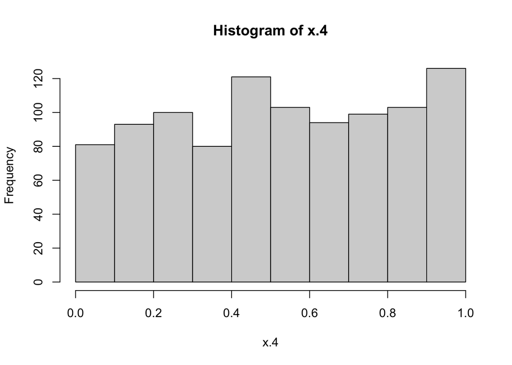

```r
x.4 <- runif(1000)
hist(x.4)
```

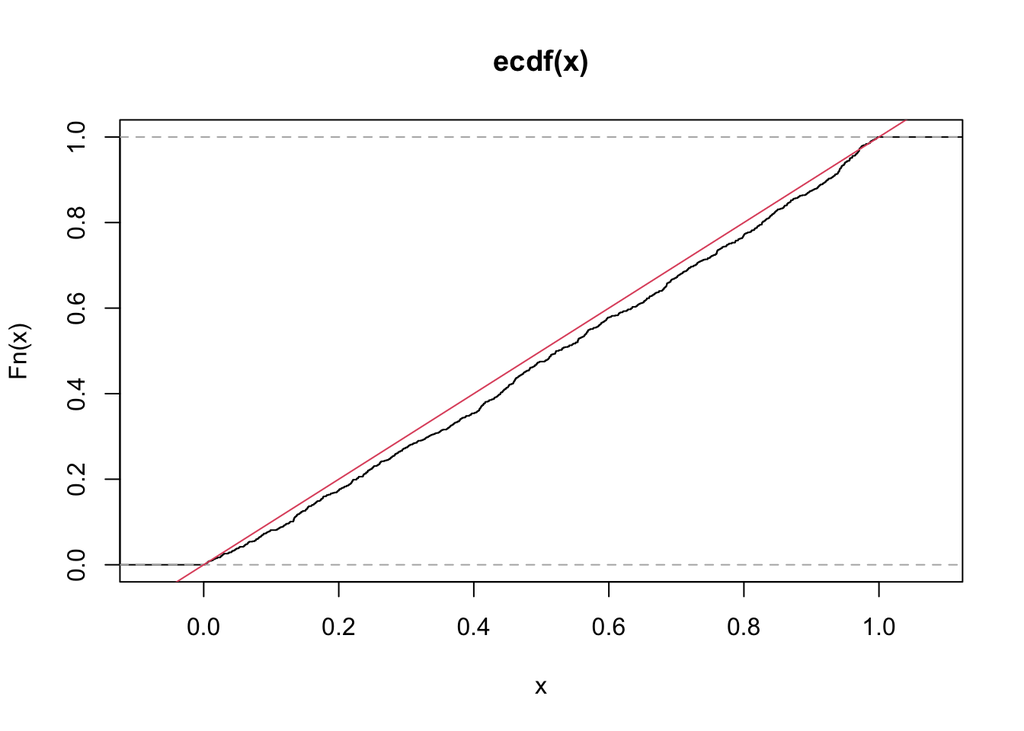

```r
plot.ecdf(x.4)
abline(a=0,b=1, col = 2)
```

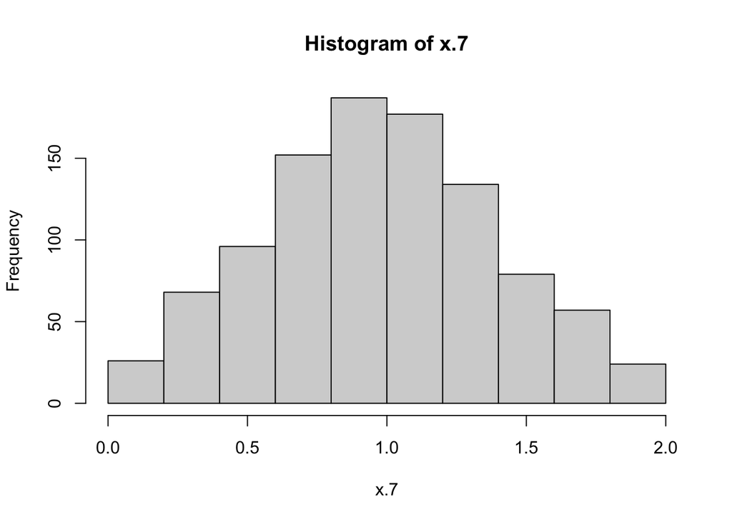

```r
x.5 <- runif(1000)
x.6 <- runif(1000)
x.7 = x.5 + x.6
hist(x.7)
```

- A: The distribution of $X_1 +X_2$ uniform is not Uniform. When we plot the histogram, we can clearly see that the frequency of the distribution is higher in the middle and decreases gradually.
2. Is the distribution of $X_1.X_2$ uniform? Please Justify your answer.

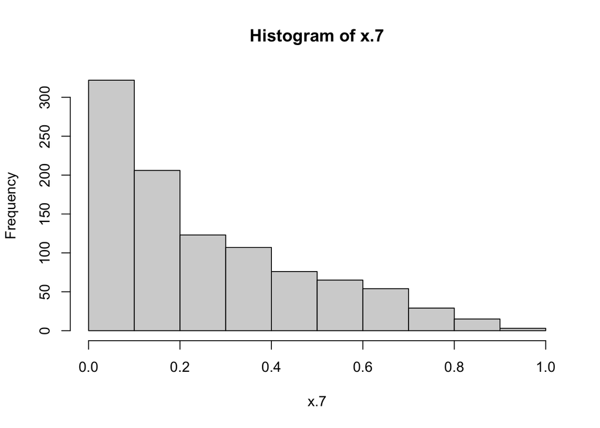

```r
x.5 <- runif(1000)
x.6 <- runif(1000)
x.7 = x.5 * x.6
hist(x.7)
```

- A: The distribution of $X_1.X_2$ is not Uniform. when we plot the histogram, we can clearly see that the frequency of the distribution is strictly decreasing and not uniform.
3. Is the distribution of $max(X_1, X_2)$ or $min(X_1, X_2)$ uniform? Please Justify your answer.

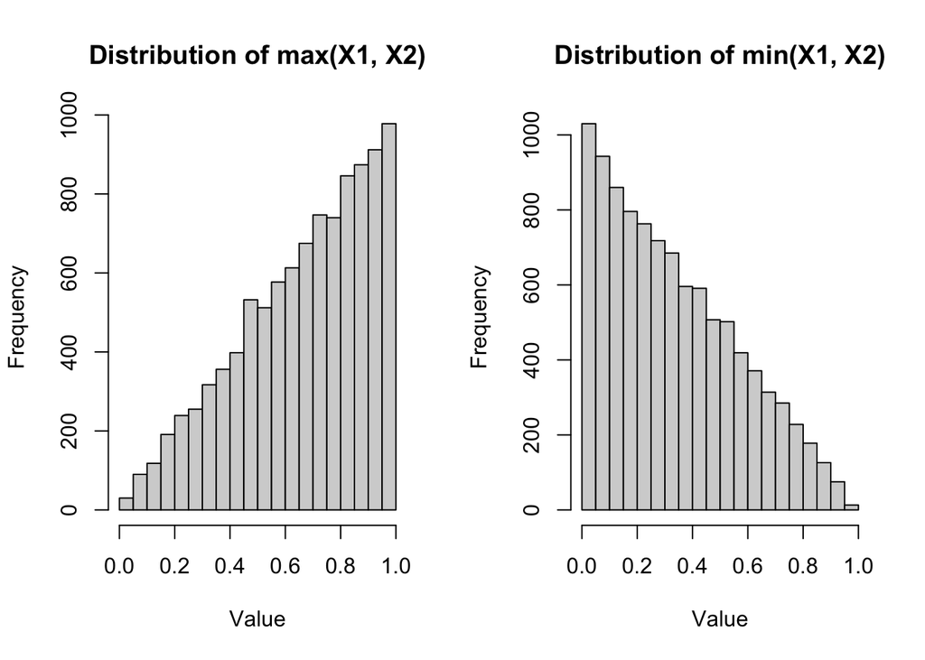

```r
n_simulations <- 10000

# Initialize vectors to store maximum and minimum values
max_values <- numeric(n_simulations)
min_values <- numeric(n_simulations)

# Perform simulations
for (i in 1:n_simulations) {
  # Generate random values for X1 and X2 from a uniform distribution for simplicity
  X1 <- runif(1)
  X2 <- runif(1)

  # Calculate the maximum and minimum of X1 and X2
  max_values[i] <- max(X1, X2)
  min_values[i] <- min(X1, X2)
}

# Create histograms to visualize the distributions
par(mfrow=c(1, 2))

hist(max_values, breaks = 20, main = "Distribution of max(X1, X2)", xlab = "Value")
hist(min_values, breaks = 20, main = "Distribution of min(X1, X2)", xlab = "Value")
```

- A: The distribution of $max(X_1, X_2)$ and $min(X_1, X_2)$ is not uniform. When we plot the graph, we can see it is not uniform.
4. Is the distribution of $1-X_1$ uniform? Please Justify your answer.

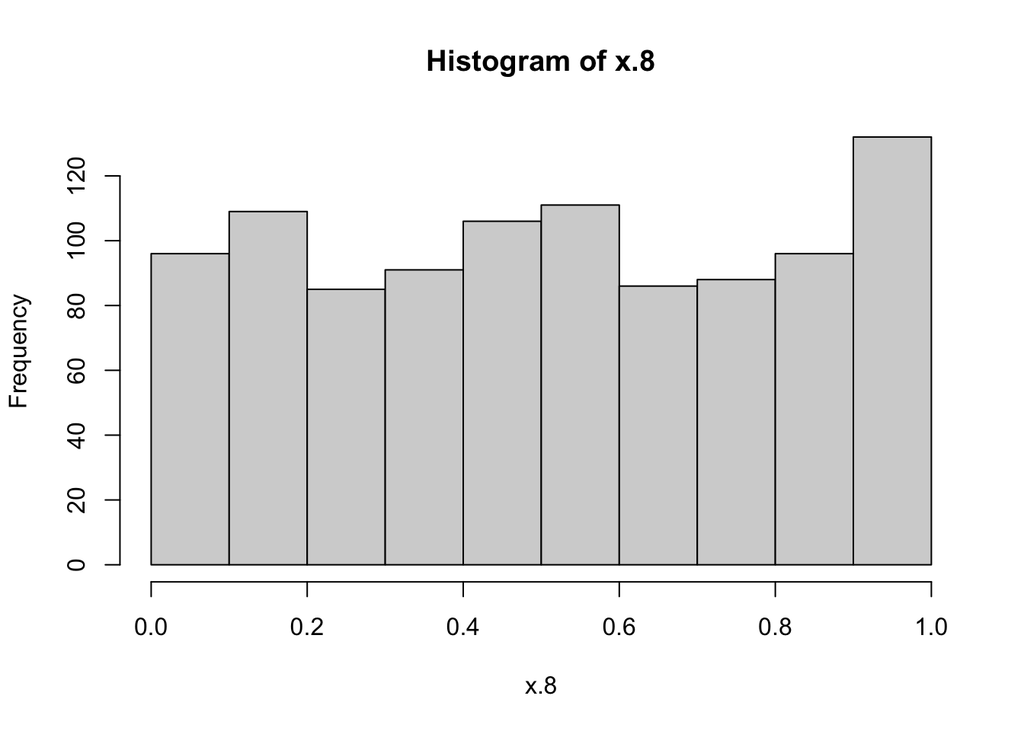

```r
x.5 <- runif(1000)
x.6 <- runif(1000)
x.8 = 1-x.5
hist(x.8)
```

- A: The distribution of $1-X_1$ is almost uniform. When we plot the graph, we can see the frequency distribution tends to be uniform for all values of x.8

## Problem 2:

Validate the following theorems using simulation. (You can use parameters of your choice)

`optional`: In addition to the simulation, you can also prove these theorems analytically, i.e. with pen and paper, if you want.

1. Linear Transformations

**Theorem-5.6.4:** If $X$ has the normal distribution with mean $\mu$ and variance $\sigma^2$ and if $Y=a X+b$, 5.6.4 where $a$ and $b$ are given constants and $a \neq 0$, then $Y$ has the normal distribution with mean $a \mu+b$ and variance $a^2 \sigma^2$.

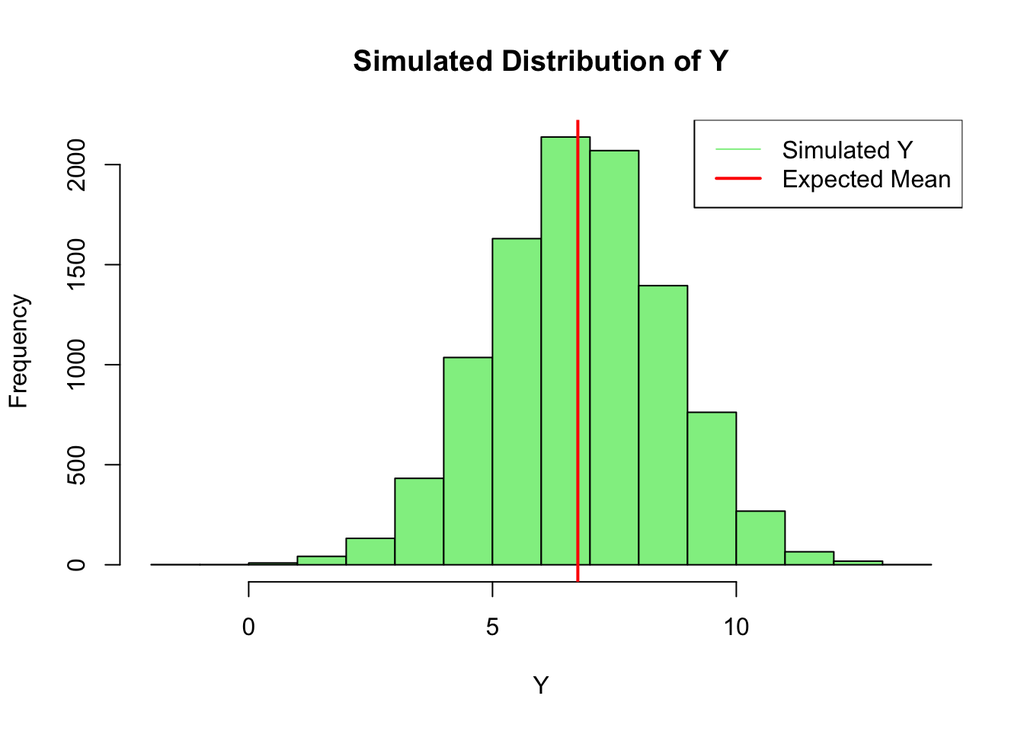

```r
# Set parameters
mu <- 2.5
sigma <- 1.2
a <- 1.5
b <- 3.0

# Number of simulations
n_simulations <- 10000

# Simulate random variable X with a normal distribution
X <- rnorm(n_simulations, mean = mu, sd = sigma)

# Create the new random variable Y using the transformation
Y <- a * X + b

# Calculate the mean and variance of Y
mean_Y <- mean(Y)
variance_Y <- var(Y)

# Expected mean and variance of Y
expected_mean_Y <- a * mu + b
expected_variance_Y <- (a^2) * (sigma^2)

#Plotting histogram
hist(Y, main = "Simulated Distribution of Y", xlab = "Y", col = "lightgreen")
abline(v = expected_mean_Y, col = "red", lwd = 2)
legend("topright", legend = c("Simulated Y", "Expected Mean"), col = c("lightgreen", "red"), lwd = c(1, 2))
```

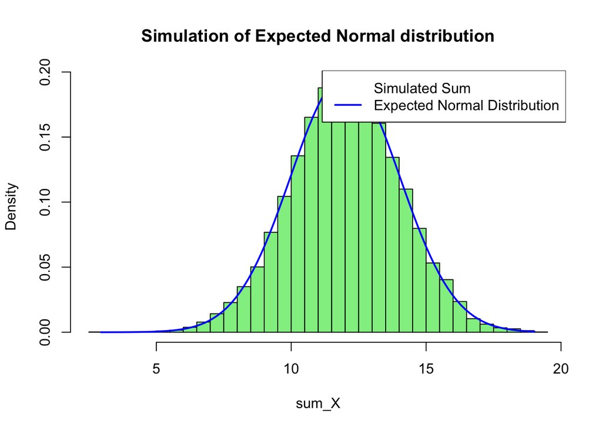

```r
# Set the parameters
k <- 5  # Number of independent random variables
means <- c(2, 3, 1, 4, 2)
variances <- c(0.5, 1, 1.5, 0.8, 0.3)

# Simulate random variables X1, X2, ..., Xk
set.seed(909090)  # For reproducibility
samples <- matrix(0, nrow = 10000, ncol = k)
for (i in 1:k) {
  samples[, i] <- rnorm(10000, mean = means[i], sd = sqrt(variances[i]))
}

sum_X <- rowSums(samples)

expm <- sum(means)
expv <- sum(variances)


hist(sum_X, breaks = 50, probability = TRUE, col = "lightgreen", main = "Simulation of Expected Normal distribution")
curve(dnorm(x, mean = expm, sd = sqrt(expv)), from = min(sum_X), to = max(sum_X), col = "blue", lwd = 2, add = TRUE)
legend("topright", legend = c("Simulated Sum", "Expected Normal Distribution"), col = c("lightgreen", "blue"), lwd = c(0, 2))
```

## Problem 3:

Use the iris data set to check the normality of Sepal width of setosa using the following normality tests (Repeat the steps in the example 3 in lab 4, comment on your results)

1. Anderson Darling Test

```r
library(nortest)
my_data <- iris
my_data_set <- iris$Sepal.Width[iris$Species == "setosa"]
ad_test_result <- ad.test(my_data_set)
shapiro_test_result <- shapiro.test(my_data_set)
ad_test_result
```

```
    Anderson-Darling normality test

data:  my_data_set
A = 0.49096, p-value = 0.2102
```

```r
shapiro_test_result
```

```
    Shapiro-Wilk normality test

data:  my_data_set
W = 0.97172, p-value = 0.2715
```

- Anderson-Darling Test: The p-value from the Anderson-Darling test is 0.2102. Since this p-value is greater than the typical significance level of 0.05, we fail to reject the null hypothesis. This suggests that the data may follow a normal distribution.
- Shapiro-Wilk Test: The p-value from the Shapiro-Wilk test is 0.2715. Similar to the Anderson-Darling test, this p-value is greater than 0.05, leading to the same conclusion. We fail to reject the null hypothesis, indicating that the data may follow a normal distribution.
2. Kolmogorov-Smirnov Test (Comapre to a standard normal distribution)

```r
my_data <- iris
my_data_set <- iris$Sepal.Width[iris$Species == "setosa"]
ks_test_result <- ks.test(my_data_set,"pnorm")
ks_test_result
```

```
    One-sample Kolmogorov-Smirnov test

data:  my_data_set
D = 0.98928, p-value < 2.2e-16
alternative hypothesis: two-sided
```

- The p-value obtained from the KS test is extremely small (p-value < 2.2e-16), well below the typical significance level of 0.05. This means that the data significantly deviates from a standard normal distribution

## Problem 4: (optional)

`Exponential Distribution`

Given exponentially distributed random variables $X_1, . . . , X_k$ . Think of waiting times for independent random alarm clocks $1,...,k$ to go off.

Which of these are again exponentially distributed? Explore with a simulation. (Hint: you can use many methods here to compare the distributions, for example; using Kolmogorov-Smirnov Test, plotting cdfs or ecdfs(as we did in lab 3),..etc )

1. Distribution of $min(X_1,\dots,X_k)$? Waiting time for the first alarm to go off.
2. Distribution of $max(X_1, \dots, X_k )$? Waiting time for the last alarm to go off.
3. Distribution of $X_1 + \dots + X_k$ ? Waiting time until Start of the next clock when the previous alarm/s has gone off.